# PA1_template.Rmd

Giuseppa Cefalu

July 31, 2019

# **Personal Movement From Activity Monitoring Devices** **Abstract**

**Purpose:** To determine weather inputing missing data values makes a difference in the shape of the distribution of the total number of steps taken each day recorded by monitoring devices colleted over a period of months (October and November) at 5 minute inrervals and on the average daliy activity pattern. The data for this analysis can be downloaded from the “Reproducible reserach class web site” [activity monitoring data] (https://www.coursera.org/learn/reproducible-research/peer/gYyPt/course-project-1.

A new data set containing the original and inputed data was created and the total number of steps taken daily in 5 minute intervals was calculated. A histogram of the total number of steps taken daily in 5 minute intervals was made and the mean and meddian of the total number of steps taken daily was calculated.

**Results:**Inputing missing data makes a great difference in the shape, mean and median of the distrinution. The mean and median of the distribution with inputed data is grater than the mean and median of the original data.

```r
 rm(list = ls())
 library(dplyr)
```

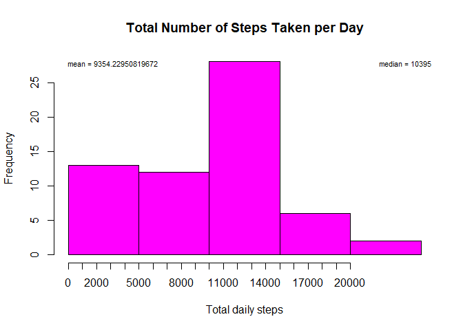

```r
 library(ggplot2)
 library(lattice)

 # Define the path to the data file
file_path <- file.path(getwd(), "activity data") #, stringsAsFactors = FALSE))

# Read data from file
data <- read.csv(file.path(file_path, "activity.csv"))

# total number of steps taken per day
total_steps_day <- data %>% group_by(date) %>% summarize(total = sum(steps, na.rm = TRUE))

# Histogram of the total number of steps taken per day
hist(total_steps_day$total, xaxt = "n", main = "Total Number of Steps Taken per Day", xlab = "Total daily steps", col = "magenta")
axis(side=1, at=seq(0,20000, 1000))

# Calculate the mean of the total number of steps taken per day
mean_total_daily_steps <- mean(total_steps_day$total)

# Calculate the median of the total number of steps taken per day
median_total_daily_steps <- median(total_steps_day$total)

# Report on graph legend the mean of the total number of steps taken per day
legend('topleft',legend=parse(text=sprintf('paste(mean,\' = %s\')',mean_total_daily_steps)),bty='n', cex = 0.70);

# Report on graph legend the median of the total number of steps taken per day
legend('topright',legend=parse(text=sprintf('paste(median,\' = %s\')',median_total_daily_steps)),bty='n', cex = 0.70)
```

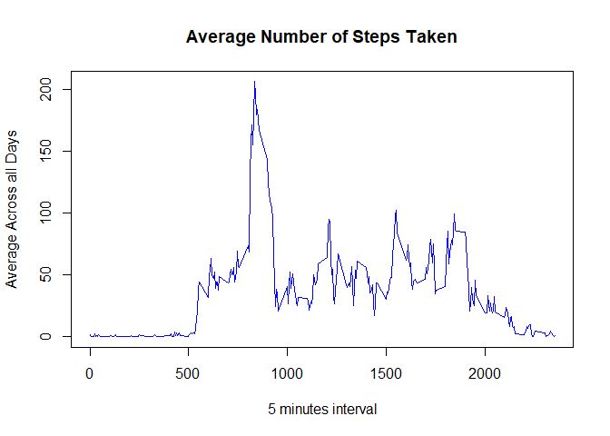

```r
average_daily_steps <- tapply(data$steps, data$interval, mean, na.rm = TRUE)

# Plot a time series of the average number of steps averaged across all days versus
# the 5 minutes interval
plot(row.names(average_daily_steps), average_daily_steps, type = "l", xlab = "5 minutes interval", ylab = "Average Across all Days", main = "Average Number of Steps Taken", col = "blue")
```

```r
# Wich 5 minute interval on average across all days inthe data set contains the
# maximum number of steps
max_interval <- which.max(average_daily_steps)
#names(max_interval)

# Calculate and report the total number of missing values in the data set
# (i.e The total number of rows with NAs)
data_rows_with_NA <- sum(is.na(data))
data_rows_with_NA
```

```
## [1] 2304
```

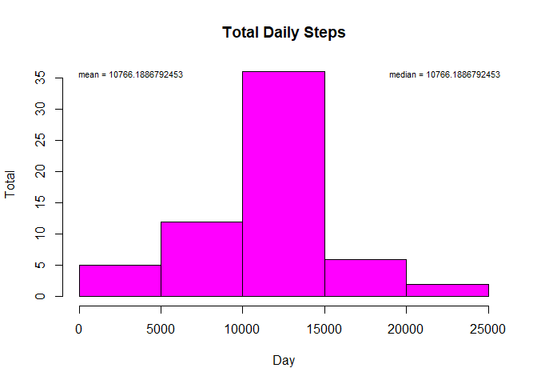

```r
# Calculate a mean value of steps per interval to input missing values
average_steps_in_interval <- data %>% group_by(interval) %>% summarize(total = mean(steps, na.rm = TRUE))

# Declare a vector of type numeric to store the inputed and non-inputed number of steps
noNA_data <- numeric()

# Iterate through the data and substitute NA values by the mean value of steps on a 5 minute interval
for(i in 1:nrow(data)){
    row <- data[i ,]
    if(is.na(row$steps)){
        steps <- subset(average_steps_in_interval, interval == row$interval)$total
    }else{
        steps <- row$steps
    }
      noNA_data <- c(noNA_data, steps)
}

# Copy data into new data frame
new_data <- data

# Insert inputed values into new data set steps variable
new_data$steps <- noNA_data

# Total number of steps taken each day
total_steps_day <- new_data %>% group_by(date) %>% summarize(total = sum(steps, na.rm = TRUE))

# Mean of the number of steps taken each day
Mean = mean(total_steps_day$total)

# Median of the total number of steps taken each day
Median = median(total_steps_day$total)

# Histogram of he total number of steps taken each day
hist(total_steps_day$total, main = "Total Daily Steps", xlab = "Day", ylab = "Total", col = "magenta")

# Report in the histogram legend the mean of steps taken each day
legend('topleft',legend=parse(text=sprintf('paste(mean,\' = %s\')',Mean)),bty='n', cex = 0.70);

# Report in the histogram legen the median number of steps taken each day
legend('topright',legend=parse(text=sprintf('paste(median,\' = %s\')',Median)),bty='n', cex = 0.70)
```

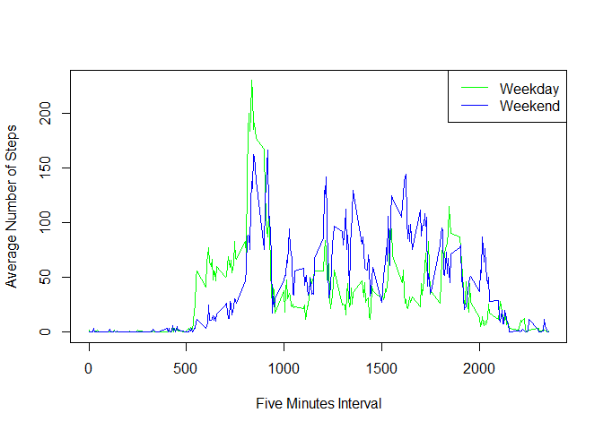

```r
# What is the impact of imputing missing data on the estimates of the total
# daily number of steps? The shape of the distribution changes completely

# Convert dates to days of the week
week_days <- weekdays(as.Date(new_data$date))

# Declalre a vector to store the weekdays and weekends
day <- vector()

# if the day of the week is Saturday or Sunday store weekend else store weekday
# in the day vector
for(i in 1:nrow(new_data)){
    if(week_days[i] == "Saturday"){
        day[i] = "Weekend"

    }else if(week_days[i] == "Sunday"){
        day[i] = "Weekend"

    }else{
        day[i] = "Weekday"
    }

}

# Add the day vector to the new_data dataframe
new_data = mutate(new_data, day = day)

# Calculate the average number of steps taken each day
average <- new_data %>% group_by(interval, day) %>% summarize(steps = mean(steps, na.rm = TRUE))

# Calculate the median number of steps taken each day
median <- new_data %>% group_by(interval, day) %>% summarize(steps = median(steps, na.rm = TRUE))

# ARE THERE DIFFERENCES IN ACTIVITY PATTERNS BETWEEN WEEKDAYS AND WEEKENDS

# Plot the average number of steps taken across all days verus the 5 minutes interval
# using base plotting system
plot(average$interval, average$steps, xlab = "Five Minutes Interval", ylab = "Average Number of Steps",type = 'n')

# Extract the set with weekday factor variable
get_day  <- filter(average, day == "Weekday")

# Extract the set with the weekend factor variable
get_weekend <- filter(average, day == "Weekend")
lines(get_day$interval, get_day$steps, col = "green")
lines(get_weekend$interval, get_weekend$steps, col = "blue")
legend("topright", c("Weekday", "Weekend"), lty = c(1,1), col = c("green", "blue"))
```

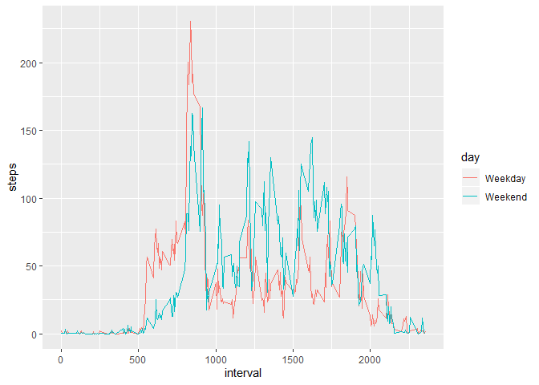

```r
# Plot the average number of steps taken across all days versus 5 minute intervals
# Using the ggplot2 graphics system
p <- ggplot(average, aes(interval, steps)) + geom_line(aes(color = day))

# Display ggplot
print(p)
```

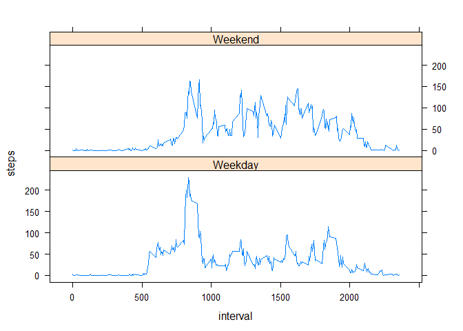

```r
# Plot the average number of steps taken across all days versus the 5 minute intervals
# using lattice system (panel plot)
pl <- xyplot(steps ~ interval | factor(day), average, type = "l", layout = c(1,2))

# Display plot
print(pl)
```